# Choosing MGB Biobank asthmatic subject/samples for further omics study

Sample size by varying criteria

MHuang

2/18/2021

# 1. Read in selection pool

Exclude:

- subjects with no plasma sample
- non-asthmatics

```r
pool <- fread(pool_fname); nrow(pool)
```

```
## [1] 8766
```

Lung function data variable names:

- n_pul_rec: number of pulmonary function test (pft, spirometry) records
- earliest_pul_rec: date of earliest pft record
- latest_pul_rec: date of latest pft record
- has_pul_rec: has any pft record

Medication data variable names:

- n_ics_rec: number of ICS prescription records
- ics_rec_latest_timegap_d: date of latest ICS prescription - last plasma date in days
- has_ics_rec: has ICS prescription records
- n_ocs_rec: number of OCS prescription records
- ocs_rec_latest_timegap_d: date of latest OCS prescription - last plasma date in days
- has_ocs_rec: has OCS prescription records

Asthma exacerbations & severity, adrenal insufficiency variable names:

- n_exac_dia: number of asthma exacerbation diagnoses
- has_exac_dia: has asthma exacerbation diagnoses
- n_sevr_dia: number of asthma severity diagnoses
- has_sevr_dia: has asthma severity diagnoses
- n_adrinsuf_dia: number of adrenal insufficiency diagnoses
- has_adrinsuf_dia: has adrenal insufficiency diagnoses

Suffix:

- _alltime: all time in system
- _bflastpl: all time prior to last plasma date
- _10ybflastpl: within 10 years prior to last plasma date
- _5ybflastpl: within 5 years prior to last plasma date
- _4ybflastpl: within 4 years prior to last plasma date
- _3ybflastpl: within 3 years prior to last plasma date
- _2ybflastpl: within 2 years prior to last plasma date
- _1ybflastpl: within 1 year prior to last plasma date

BMI/lab test data variable names (bmi as example, replace with acth/cortisol/eos/ige):

- bmi: BMI value of a single record
- bmi_date: date of BMI record
- n_bmi_rec: number of BMI records
- bmi_all_values: list of all BMI values
- bmi_all_dates: list of all BMI record dates
- bmi_median: median BMI among all values
- bmi_min: minimum BMI among all values
- bmi_max: maximum BMI among all values
- bmi_mean: mean BMI averaged across all values
- bmi_closest_timegap_d: date of closest BMI record - last plasma date in days

Suffix:

- _closest_lastpl: closest record to last plasma date
- _pm3y_lastpl: plus or minus 3 years around last plasma date
- _pm2y_lastpl: plus or minus 2 years around last plasma date
- _pm1y_lastpl: plus or minus 1 year around last plasma date

Others:

- Age
- Gender
- race
- asthma_ppv: range 0.82 - 0.95
- copd_existence: Yes/No (Biobank algorithm)
- copd_ppv: range 0.75 - 0.94
- smk_ever_alltime: ever has a record of former/current smoking during all time in MGB system

# 2. General demographics

## 2.1. All subjects in pool

```r
pool[, summary(Age)]
```

```
##    Min. 1st Qu.  Median    Mean 3rd Qu.    Max.
##    7.00   41.00   57.00   54.82   68.00   98.00
```

```r
pool[, .N, .(`age>=18` = Age >= 18)]
```

```
##    age>=18    N
## 1:    TRUE 8714
## 2:   FALSE   52
```

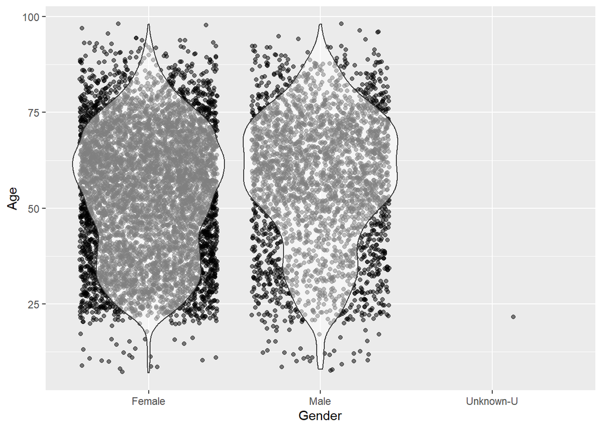

```r
ggplot(pool, aes(x = Gender, y = Age)) +
        geom_jitter(alpha = 0.5) +
        geom_violin(alpha = 0.5)
```

```r
pool[, .N, race][order(-N)][, pct := N/sum(N)*100] %>% print(digits = sig_digits - 1)
```

```
##                             race    N    pct
## 1:                         White 7103 81.029
## 2:                         Black  586  6.685
## 3:                         Other  338  3.856
## 4:                      Hispanic  334  3.810
## 5:                       Unknown  200  2.282
## 6:                         Asian  181  2.065
## 7: American Indian/Alaska Native   21  0.240
## 8:     Hawaiian/Pacific Islander    3  0.034
```

```r
pool[, .N, copd_existence]
```

```
##    copd_existence    N
## 1:             No 8470
## 2:            Yes  296
```

```r
pool[, .N, smk_ever_alltime]
```

```
##    smk_ever_alltime    N
## 1:                1 3496
## 2:                0 4631
## 3:               NA  639
```

```r
## Median BMI from within (+/-)1 year against BMI closest to last plasma date

pool[, .N, .(has_bmi_closest_lastpl, has_bmi_rec_pm1y_lastpl)]
```

```
##    has_bmi_closest_lastpl has_bmi_rec_pm1y_lastpl    N
## 1:                      1                       1 7472
## 2:                      1                       0  741
## 3:                      0                       0  553
```

```r
pool[, summary(bmi_closest_timegap_d_pm1y_lastpl)]
```

```
##     Min.  1st Qu.   Median     Mean  3rd Qu.     Max.     NA's
## -364.000   -3.000    0.000   -1.025    3.000  365.000     1294
```

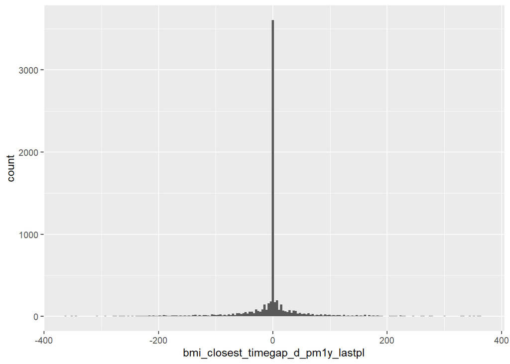

```r
ggplot(pool) + geom_histogram(aes(x = bmi_closest_timegap_d_pm1y_lastpl), bins = 200)
```

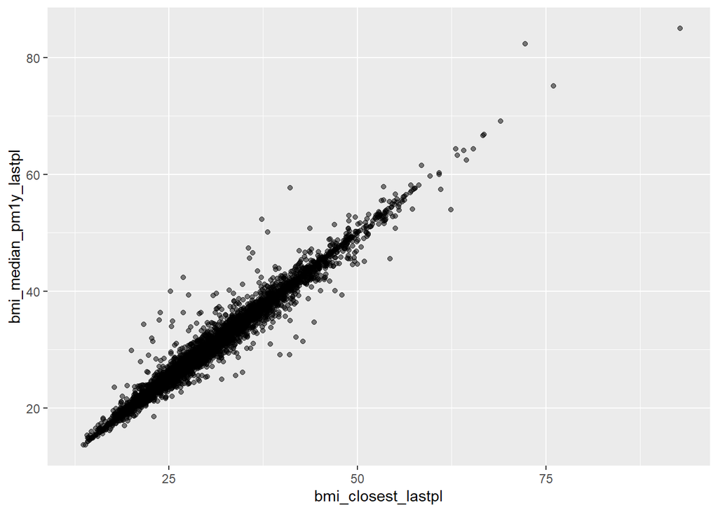

```r
ggplot(pool, aes(x = bmi_closest_lastpl, y = bmi_median_pm1y_lastpl)) +
        geom_point(alpha = 0.5)
```

# 3. Pulmanory function test (pft) data availability

## 3.1. 2+ pft records

```r
pool[Age >= 18 & n_pul_rec_alltime >= 2, .N]
```

```
## [1] 1881
```

```r
pool[Age >= 18 & n_pul_rec_alltime >= 2, summary(Age)]
```

```
##    Min. 1st Qu.  Median    Mean 3rd Qu.    Max.
##   19.00   54.00   65.00   62.79   73.00   96.00
```

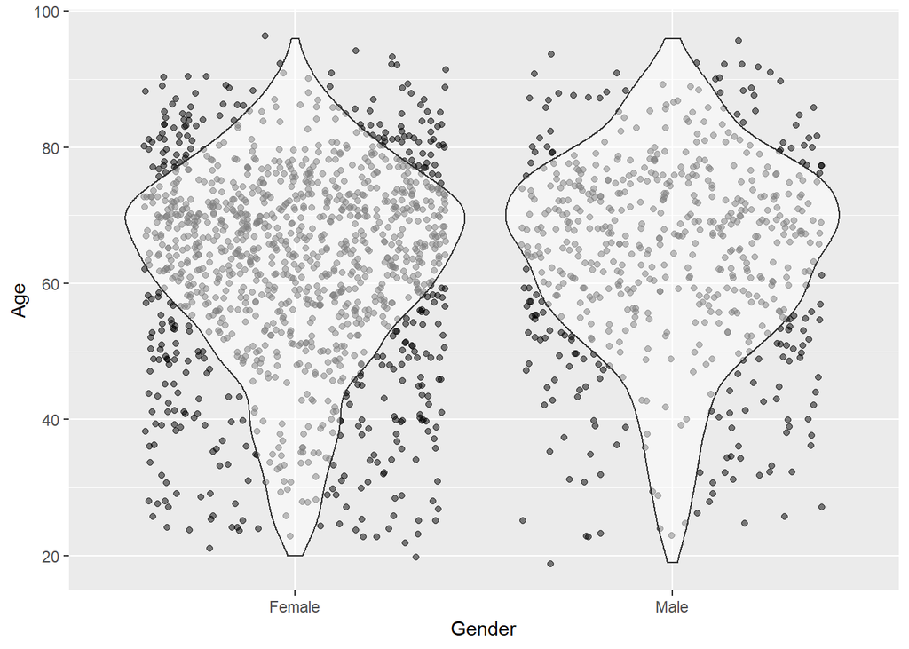

```r
ggplot(pool[Age >= 18 & n_pul_rec_alltime >= 2, ], aes(x = Gender, y = Age)) +
        geom_jitter(alpha = 0.5) +
        geom_violin(alpha = 0.5)
```

```r
pool[Age >= 18 & n_pul_rec_alltime >= 2, .N, race
     ][order(-N)][, pct := N/sum(N)*100] %>% print(digits = sig_digits - 1)
```

```
##                             race    N   pct
## 1:                         White 1526 81.13
## 2:                         Black  154  8.19
## 3:                         Other   85  4.52
## 4:                      Hispanic   49  2.60
## 5:                       Unknown   37  1.97
## 6:                         Asian   26  1.38
## 7: American Indian/Alaska Native    4  0.21
```

```r
pool[Age >= 18 & n_pul_rec_alltime >= 2, .N, copd_existence]
```

```
##    copd_existence    N
## 1:             No 1688
## 2:            Yes  193
```

```r
pool[Age >= 18 & n_pul_rec_alltime >= 2, .N, smk_ever_alltime]
```

```
##    smk_ever_alltime   N
## 1:                1 935
## 2:                0 879
## 3:               NA  67
```

```r
## Median BMI from within (+/-)1 year against BMI closest to last plasma date

pool[Age >= 18 & n_pul_rec_alltime >= 2, .N, .(has_bmi_closest_lastpl, has_bmi_rec_pm1y_lastpl)]
```

```
##    has_bmi_closest_lastpl has_bmi_rec_pm1y_lastpl    N
## 1:                      1                       1 1782
## 2:                      1                       0   85
## 3:                      0                       0   14
```

```r
pool[Age >= 18 & n_pul_rec_alltime >= 2, summary(bmi_closest_timegap_d_pm1y_lastpl)]
```

```
##     Min.  1st Qu.   Median     Mean  3rd Qu.     Max.     NA's
## -360.000   -3.000    0.000   -1.768    2.000  359.000       99
```

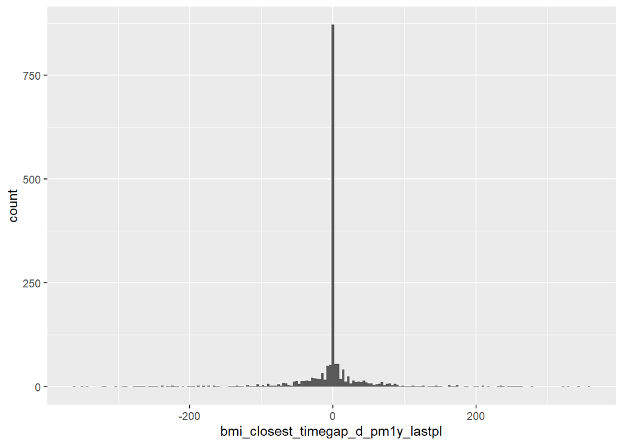

```r
ggplot(pool[Age >= 18 & n_pul_rec_alltime >= 2, ]) +
        geom_histogram(aes(x = bmi_closest_timegap_d_pm1y_lastpl), bins = 200)
```

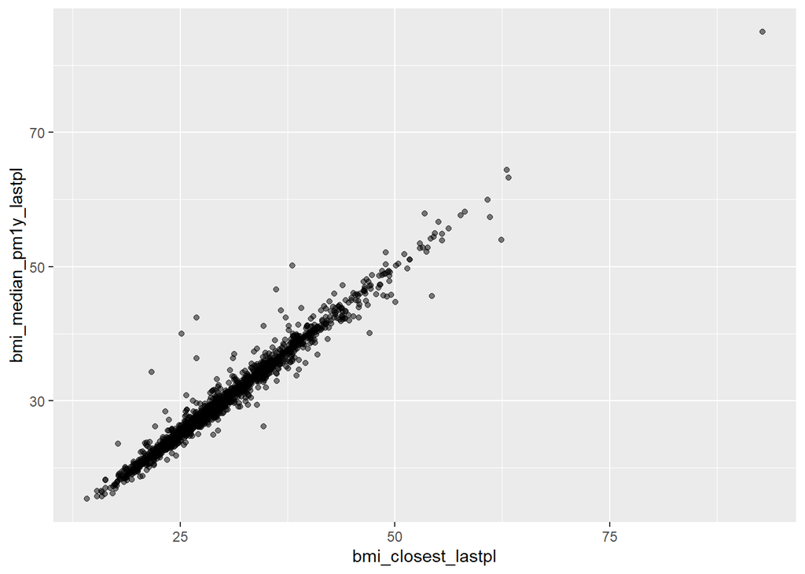

```r
ggplot(pool[Age >= 18 & n_pul_rec_alltime >= 2, ],
       aes(x = bmi_closest_lastpl, y = bmi_median_pm1y_lastpl)) +
        geom_point(alpha = 0.5)
```

```r
## Timing of pul record

pool[n_pul_rec_alltime >= 2 & Age >= 18, .N, .(has_pul_1ybf = closest_pul_rec_bf_timegap_d_alltime >= -365)]
```

```
##    has_pul_1ybf   N
## 1:        FALSE 999
## 2:         TRUE 659
## 3:           NA 223
```

```r
pool[n_pul_rec_alltime >= 2 & Age >= 18, .N, .(has_pul_1yaf = closest_pul_rec_af_timegap_d_alltime <= 365)]
```

```
##    has_pul_1yaf   N
## 1:           NA 722
## 2:         TRUE 654
## 3:        FALSE 505
```

```r
pool[n_pul_rec_alltime >= 2 & Age >= 18, ][closest_pul_rec_bf_timegap_d_alltime >= -365*5 |
                                             closest_pul_rec_af_timegap_d_alltime <= 365*5, .N]
```

```
## [1] 1559
```

```r
pool[n_pul_rec_alltime >= 2 & Age >= 18, ][closest_pul_rec_bf_timegap_d_alltime >= -365 &
                                             closest_pul_rec_af_timegap_d_alltime <= 365, .N]
```

```
## [1] 382
```

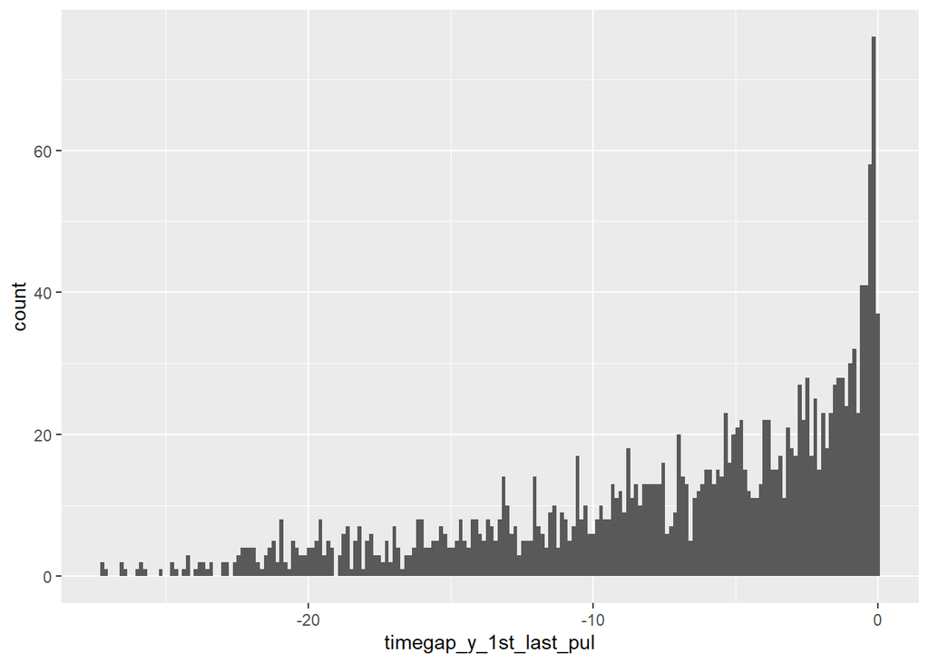

```r
## Timegap between 1st and last pul records

pool[n_pul_rec_alltime >= 2 & Age >= 18,
     timegap_y_1st_last_pul := as.numeric(as.Date(earliest_pul_rec_alltime, "%Y-%m-%d") -
                                            as.Date(latest_pul_rec_alltime, "%Y-%m-%d"))/365.25]
ggplot(pool[n_pul_rec_alltime >= 2 & Age >= 18, ]) +
        geom_histogram(aes(timegap_y_1st_last_pul), bins = 200)
```

```r
pool[n_pul_rec_alltime >= 2 & Age >= 18, .N, .(timegap_y_1st_last_pul <= -1)]
```

```
##    timegap_y_1st_last_pul    N
## 1:                   TRUE 1546
## 2:                  FALSE  335
```

```r
pool[Age >= 18 & n_pul_rec_alltime >= 2, .(in_pegasus1, n_pul_rec_alltime, closest_pul_rec_bf_timegap_d_alltime,
                                           closest_pul_rec_af_timegap_d_alltime, timegap_y_1st_last_pul,
                                           has_bmi_closest_lastpl, has_bmi_rec_pm1y_lastpl,
                                           asthma_ppv, Age, copd_existence, smk_ever_alltime,
                                           n_ics_rec_5ybflastpl, n_ocs_rec_5ybflastpl, n_exac_dia_5ybflastpl,
                                           n_sevr_dia_5ybflastpl, n_ige_rec_pm1y_lastpl, n_cortisol_rec_pm1y_lastpl,
                                           n_acth_rec_pm1y_lastpl, n_eos_rec_pm1y_lastpl)] %>%
        datatable(filter = "top")
```

|  | in_pegasus1 | n_pul_rec_alltime | closest_pul_rec_bf_timegap_d_alltime | closest_pul_rec_af_timegap_d_alltime | timegap_y_1st_last_pul | has_bmi_closest_lastpl | has_bmi_rec_pm1y_lastpl | asthma_ppv | Age | copd_existence | smk_ever_alltime | n_ics_rec_5ybflastpl | n_ocs_rec_5ybflastpl | n_exac_dia_5ybflastpl | n_sevr_dia_5ybflastpl | n_ige_rec_pm1y_lastpl | n_cortisol_rec_pm1y_lastpl | n_acth_rec_pm1y_lastpl | n_eos_rec_pm1y_lastpl |
| --- | --- | --- | --- | --- | --- | --- | --- | --- | --- | --- | --- | --- | --- | --- | --- | --- | --- | --- | --- |
| 1 | 0 | 12 | -2208 |  | -6.14647501711157 | 1 | 1 | 0.93 | 73 | No | 1 | 15 | 9 | 2 | 2 |  |  |  | 1 |
| 2 | 1 | 57 | -148 | 250 | -25.8535249828884 | 1 | 1 | 0.95 | 71 | No | 1 | 18 | 29 | 7 |  | 1 |  |  | 9 |
| 3 | 0 | 2 |  | 1486 | -1.45653661875428 | 1 | 1 | 0.95 | 76 | No | 1 | 8 | 17 |  |  |  |  |  | 3 |
| 4 | 0 | 5 | -1061 |  | -3.61122518822724 | 1 | 1 | 0.93 | 72 | No | 1 | 13 | 0 | 1 | 4 |  |  |  | 4 |
| 5 | 0 | 4 | -18 |  | -8.23545516769336 | 1 | 1 | 0.95 | 78 | Yes | 1 | 25 | 25 | 5 |  |  |  |  | 7 |
| 6 | 0 | 3 | -1772 | 862 | -8.34223134839151 | 1 | 1 | 0.9 | 80 | No | 1 | 9 | 3 |  |  |  |  |  | 8 |
| 7 | 1 | 2 | -1877 |  | -3.75633127994524 | 1 | 1 | 0.93 | 68 | No | 0 | 24 | 11 | 1 |  |  | 2 |  | 35 |
| 8 | 0 | 3 | -1896 |  | -4.46817248459959 | 1 | 1 | 0.91 | 88 | No | 0 | 27 | 6 | 24 | 7 |  |  |  | 3 |
| 9 | 0 | 2 | -103 | 212 | -0.862422997946612 | 1 | 1 | 0.9 | 72 | No | 1 | 1 | 6 |  | 1 | 1 |  |  | 6 |
| 10 | 0 | 3 | -2010 |  | -3.60574948665298 | 1 | 0 | 0.93 | 71 | No | 1 | 19 | 31 |  |  |  |  |  |  |

[output cut: 1871 more lines]

## 3.2. 1 pft record

```r
pool[Age >= 18 & n_pul_rec_alltime == 1, .N]
```

```
## [1] 1306
```

```r
pool[Age >= 18 & n_pul_rec_alltime == 1, summary(Age)]
```

```
##    Min. 1st Qu.  Median    Mean 3rd Qu.    Max.
##   18.00   49.00   60.00   58.63   70.00   96.00
```

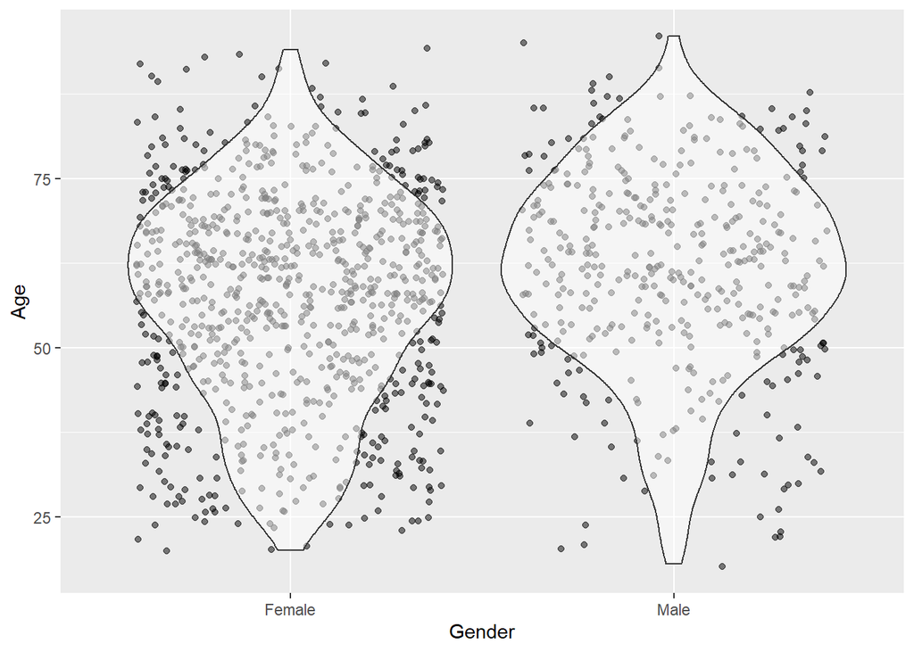

```r
ggplot(pool[Age >= 18 & n_pul_rec_alltime == 1, ], aes(x = Gender, y = Age)) +
        geom_jitter(alpha = 0.5) +
        geom_violin(alpha = 0.5)
```

```r
pool[Age >= 18 & n_pul_rec_alltime == 1, .N, race
     ][order(-N)][, pct := N/sum(N)*100] %>% print(digits = sig_digits - 1)
```

```
##                             race    N    pct
## 1:                         White 1078 82.542
## 2:                         Black   97  7.427
## 3:                      Hispanic   42  3.216
## 4:                         Other   42  3.216
## 5:                         Asian   22  1.685
## 6:                       Unknown   20  1.531
## 7: American Indian/Alaska Native    4  0.306
## 8:     Hawaiian/Pacific Islander    1  0.077
```

```r
pool[Age >= 18 & n_pul_rec_alltime == 1, .N, copd_existence]
```

```
##    copd_existence    N
## 1:             No 1265
## 2:            Yes   41
```

```r
pool[Age >= 18 & n_pul_rec_alltime == 1, .N, smk_ever_alltime]
```

```
##    smk_ever_alltime   N
## 1:                0 672
## 2:                1 582
## 3:               NA  52
```

```r
## Median BMI from within (+/-)1 year against BMI closest to last plasma date

pool[Age >= 18 & n_pul_rec_alltime == 1, .N, .(has_bmi_closest_lastpl, has_bmi_rec_pm1y_lastpl)]
```

```
##    has_bmi_closest_lastpl has_bmi_rec_pm1y_lastpl    N
## 1:                      1                       1 1196
## 2:                      1                       0   82
## 3:                      0                       0   28
```

```r
pool[Age >= 18 & n_pul_rec_alltime == 1, summary(bmi_closest_timegap_d_pm1y_lastpl)]
```

```
##     Min.  1st Qu.   Median     Mean  3rd Qu.     Max.     NA's
## -357.000   -3.000    0.000   -1.442    2.000  364.000      110
```

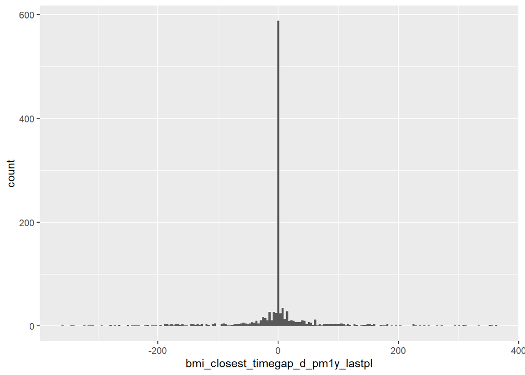

```r
ggplot(pool[Age >= 18 & n_pul_rec_alltime == 1, ]) +
        geom_histogram(aes(x = bmi_closest_timegap_d_pm1y_lastpl), bins = 200)
```

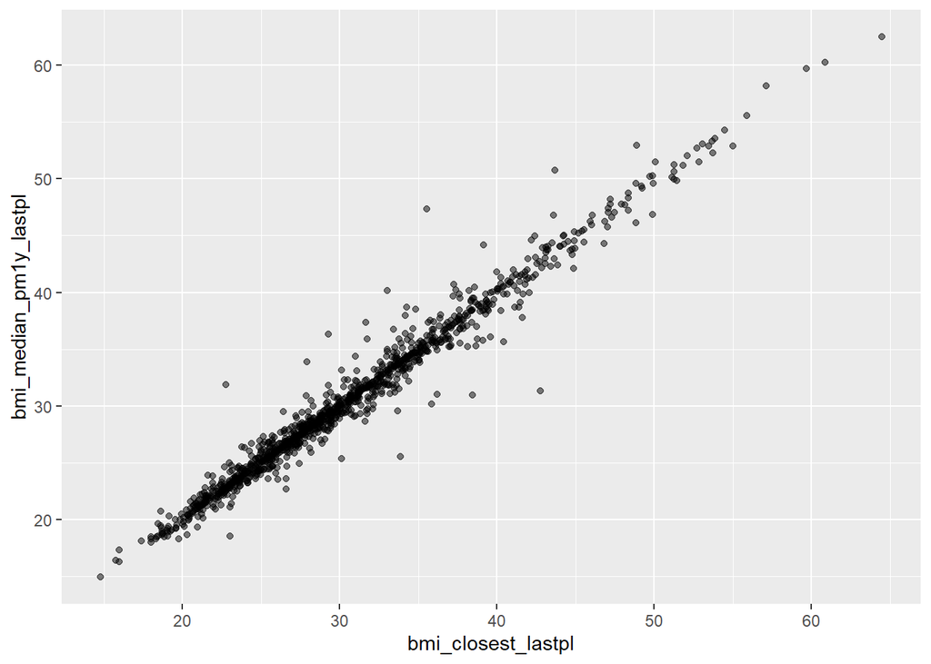

```r
ggplot(pool[Age >= 18 & n_pul_rec_alltime == 1, ],
       aes(x = bmi_closest_lastpl, y = bmi_median_pm1y_lastpl)) +
        geom_point(alpha = 0.5)
```

```r
## Timing of pul record

pool[Age >= 18 & n_pul_rec_alltime == 1, .N, .(has_pul_1ybf = closest_pul_rec_bf_timegap_d_alltime >= -365)]
```

```
##    has_pul_1ybf   N
## 1:        FALSE 753
## 2:         TRUE 134
## 3:           NA 419
```

```r
pool[Age >= 18 & n_pul_rec_alltime == 1, .N, .(has_pul_1yaf = closest_pul_rec_af_timegap_d_alltime <= 365)]
```

```
##    has_pul_1yaf   N
## 1:           NA 887
## 2:        FALSE 241
## 3:         TRUE 178
```

```r
pool[Age >= 18 & n_pul_rec_alltime == 1, ][closest_pul_rec_bf_timegap_d_alltime >= -365 |
                                             closest_pul_rec_af_timegap_d_alltime <= 365, .N]
```

```
## [1] 312
```

```r
pool[Age >= 18 & n_pul_rec_alltime == 1, .(in_pegasus1, n_pul_rec_alltime, closest_pul_rec_bf_timegap_d_alltime,
                                           closest_pul_rec_af_timegap_d_alltime, timegap_y_1st_last_pul,
                                           has_bmi_closest_lastpl, has_bmi_rec_pm1y_lastpl,
                                           asthma_ppv, Age, copd_existence, smk_ever_alltime,
                                           n_ics_rec_5ybflastpl, n_ocs_rec_5ybflastpl, n_exac_dia_5ybflastpl,
                                           n_sevr_dia_5ybflastpl, n_ige_rec_pm1y_lastpl, n_cortisol_rec_pm1y_lastpl,
                                           n_acth_rec_pm1y_lastpl, n_eos_rec_pm1y_lastpl)] %>%
        datatable(filter = "top")
```

|  | in_pegasus1 | n_pul_rec_alltime | closest_pul_rec_bf_timegap_d_alltime | closest_pul_rec_af_timegap_d_alltime | timegap_y_1st_last_pul | has_bmi_closest_lastpl | has_bmi_rec_pm1y_lastpl | asthma_ppv | Age | copd_existence | smk_ever_alltime | n_ics_rec_5ybflastpl | n_ocs_rec_5ybflastpl | n_exac_dia_5ybflastpl | n_sevr_dia_5ybflastpl | n_ige_rec_pm1y_lastpl | n_cortisol_rec_pm1y_lastpl | n_acth_rec_pm1y_lastpl | n_eos_rec_pm1y_lastpl |
| --- | --- | --- | --- | --- | --- | --- | --- | --- | --- | --- | --- | --- | --- | --- | --- | --- | --- | --- | --- |
| 1 | 0 | 1 | -5762 |  |  | 1 | 1 | 0.87 | 89 | No | 0 |  |  |  |  |  |  |  |  |
| 2 | 0 | 1 | -2295 |  |  | 1 | 1 | 0.9 | 80 | No | 0 | 3 | 0 |  |  |  |  |  | 5 |
| 3 | 0 | 1 | -145 |  |  | 1 | 1 | 0.95 | 93 | No | 1 | 9 | 2 | 2 | 1 |  |  |  | 1 |
| 4 | 1 | 1 | -1544 |  |  | 1 | 1 | 0.93 | 81 | No | 0 | 13 | 3 | 2 |  | 1 |  |  | 3 |
| 5 | 0 | 1 |  | 1991 |  | 1 | 1 | 0.93 | 72 | No | 1 | 0 | 1 |  |  |  |  |  | 11 |
| 6 | 0 | 1 | -427 |  |  | 1 | 1 | 0.87 | 86 | No | 1 | 0 | 2 |  |  |  |  |  | 3 |
| 7 | 0 | 1 | -2072 |  |  | 1 | 1 | 0.82 | 64 | No | 1 | 8 | 2 |  |  |  |  |  | 10 |
| 8 | 0 | 1 | -512 |  |  | 1 | 1 | 0.93 | 69 | No | 1 | 0 | 2 |  |  |  |  |  | 6 |
| 9 | 0 | 1 | -197 |  |  | 1 | 1 | 0.9 | 74 | No |  | 0 | 2 |  |  |  |  |  |  |
| 10 | 0 | 1 | -7354 |  |  | 1 | 0 | 0.9 | 79 | No | 0 |  |  |  |  |  |  |  |  |

[output cut: 1296 more lines]

# 4. ICS medication

```r
pool[Age >= 18, .N, .(has_ics_rec_5ybflastpl, has_ics_rec_4ybflastpl, has_ics_rec_3ybflastpl,
                      has_ics_rec_2ybflastpl, has_ics_rec_1ybflastpl)
     ][order(has_ics_rec_5ybflastpl, has_ics_rec_4ybflastpl, has_ics_rec_3ybflastpl,
             has_ics_rec_2ybflastpl, has_ics_rec_1ybflastpl)]
```

```
##    has_ics_rec_5ybflastpl has_ics_rec_4ybflastpl has_ics_rec_3ybflastpl
## 1:                      0                      0                      0
## 2:                      1                      0                      0
## 3:                      1                      1                      0
## 4:                      1                      1                      1
## 5:                      1                      1                      1
## 6:                      1                      1                      1
##    has_ics_rec_2ybflastpl has_ics_rec_1ybflastpl    N
## 1:                      0                      0 2753
## 2:                      0                      0  201
## 3:                      0                      0  300
## 4:                      0                      0  414
## 5:                      1                      0  750
## 6:                      1                      1 4296
```

```r
pool[Age >= 18, .(has_ics_rec_5ybflastpl, has_ics_rec_4ybflastpl, has_ics_rec_3ybflastpl, has_ics_rec_2ybflastpl,
                  has_ics_rec_1ybflastpl, has_acth_rec_pm1y_lastpl, has_cortisol_rec_pm1y_lastpl,
                  has_exac_dia_5ybflastpl, n_exac_dia_5ybflastpl, has_sevr_dia_5ybflastpl, n_sevr_dia_5ybflastpl,
                  has_adrinsuf_dia_5ybflastpl, n_adrinsuf_dia_5ybflastpl, has_pul_rec_5ybflastpl, n_pul_rec_5ybflastpl,
                  asthma_ppv, Age, copd_existence, has_bmi_closest_lastpl, smk_ever_alltime)] %>%
        datatable(filter = "top")
```

|  | has_ics_rec_5ybflastpl | has_ics_rec_4ybflastpl | has_ics_rec_3ybflastpl | has_ics_rec_2ybflastpl | has_ics_rec_1ybflastpl | has_acth_rec_pm1y_lastpl | has_cortisol_rec_pm1y_lastpl | has_exac_dia_5ybflastpl | n_exac_dia_5ybflastpl | has_sevr_dia_5ybflastpl | n_sevr_dia_5ybflastpl | has_adrinsuf_dia_5ybflastpl | n_adrinsuf_dia_5ybflastpl | has_pul_rec_5ybflastpl | n_pul_rec_5ybflastpl | asthma_ppv | Age | copd_existence | has_bmi_closest_lastpl | smk_ever_alltime |
| --- | --- | --- | --- | --- | --- | --- | --- | --- | --- | --- | --- | --- | --- | --- | --- | --- | --- | --- | --- | --- |
| 1 | 1 | 1 | 1 | 1 | 1 | 0 | 0 | 1 | 2 | 1 | 2 | 0 |  | 0 |  | 0.93 | 73 | No | 1 | 1 |
| 2 | 1 | 1 | 1 | 1 | 1 | 0 | 0 | 1 | 7 | 0 |  | 0 |  | 1 | 20 | 0.95 | 71 | No | 1 | 1 |
| 3 | 1 | 1 | 1 | 1 | 1 | 0 | 0 | 0 |  | 1 | 4 | 0 |  | 0 |  | 0.95 | 84 | No | 1 | 0 |
| 4 | 1 | 1 | 1 | 1 | 1 | 0 | 0 | 0 |  | 0 |  | 0 |  | 0 |  | 0.95 | 76 | No | 1 | 1 |
| 5 | 1 | 1 | 1 | 1 | 1 | 0 | 0 | 1 | 1 | 1 | 4 | 0 |  | 1 | 1 | 0.93 | 72 | No | 1 | 1 |
| 6 | 0 | 0 | 0 | 0 | 0 | 0 | 0 | 0 |  | 0 |  | 0 |  | 0 |  | 0.87 | 89 | No | 1 | 0 |
| 7 | 1 | 1 | 1 | 1 | 1 | 0 | 0 | 0 |  | 0 |  | 0 |  | 0 |  | 0.86 | 73 | No | 1 | 0 |
| 8 | 1 | 1 | 1 | 1 | 1 | 0 | 0 | 1 | 5 | 0 |  | 0 |  | 1 | 2 | 0.95 | 78 | Yes | 1 | 1 |
| 9 | 1 | 1 | 1 | 1 | 1 | 0 | 0 | 0 |  | 0 |  | 0 |  | 0 |  | 0.89 | 77 | No | 1 | 1 |
| 10 | 1 | 1 | 1 | 1 | 1 | 0 | 0 | 0 |  | 0 |  | 0 |  | 0 |  | 0.93 | 83 | No | 1 | 1 |

[output cut: 8704 more lines]